# Sesion 12: Aprendizaje bayesiano de la gaussiana multivariada

Juan Carlos Martinez-Ovando

Primavera 2017

# Objetivo

Dado un conjunto de datos $x_1,\ldots,x_n$ de vectores $p$-dimensionales, como estimar la media, $\mu$ y covarianzas $\Sigma$ (o precision $\Lambda$) si se modelan con la distribucion gaussiana $p$-variada.

# Distribuciones

La distribucion de los datos, condicional en $\mu$ y $\Sigma$ es
$$\mathbb{P}(x_1,\ldots,x_n)
= \prod_{i=1}^{n}N(x_i|\mu,\Sigma),$$
si trabajamos con la matriz de convarianzas. Sin embargo, resulta conveniente trabajar con la reparametrizacion de la distriucion en terminos de la precision
$$\Lambda=\Sigma^{-1}.$$
Asi, la verosimilitud, que es la distribucion conjunta de los datos, es
$$\mathbb{P}(x_1,\ldots,x_n)
= \prod_{i=1}^{n}N(x_i|\mu,\Lambda).$$

Concentremonos en la ultima parametrizacion. La **distribucion inicial** mas conveniente para trabajar con este modelo es la conjugada para $(\mu,\Lambda)$ dada por
$$p(\mu,\Lambda)=p(\mu|\Lambda)p(\Lambda),$$
donde
$$p(\mu|\Lambda) = N(\mu|m_0,s_0\Lambda)\\
p(\Lambda) = Wi(\Lambda|a_0,S_0),$$

- $m_0$ es el vector medio inicial para $\mu$
- $s_0\Lambda$ es la precision inicial de $\mu$
- $a_0S_0^{-1}$ es la matriz media inicial de $\Lambda$
- $(m_0,s_0,a_0,S_0)$ son hipermarametros.

La distribucion $p(\mu,\Lambda)$ se conoce como normal-Wishart.

*Esta distribucion es conveniente de usar en la practica, pues es conjugada para el modelo normal $p$-variada*.

## Aprendizaje

La distribucion final o posterior para $(\mu,\Sigma)$ resulta ser normal-Wishart (consecuencia de la conjugacidad del modelo).

*Es decir, es la misma distribucion inicial actualizando sis correspondientes hiper-parametros con la informacion contenida en los datos.*

La forma particular de la distribucion es como sigue:
$$p(\mu,\Lambda|x_1,\ldots,x_n)=p(\mu|\Lambda,x_1,\ldots,x_n)p(\Lambda,x_1,\ldots,x_n),$$
donde
$$p(\mu|\Lambda,x_1,\ldots,x_n) = N(\mu|m_n,s_n\Lambda)\\
p(\Lambda,x_1,\ldots,x_n) = Wi(\Lambda|a_n,S_n),$$
donde

$$s_n = s_0 + n\\
m_n = \frac{s_0 m_0 + n \bar{n}}{s_n} \\
a_n = a_0 + n/2\\
S_n = S_0 + (n/2)\left(\bar{S}+\frac{s_0}{s_n}(\bar{x}-m_0)(\bar{x}-m_0)'\right)$$

con

$$\bar{x}=\frac{1}{n}\sum_{i=1}^{n}x_i\\
\bar{S}=\frac{1}{n}\sum_{i=1}^{n}(x_i-\bar{x})(x_i-\bar{x})'.$$

## Prediccion

Con base en los datos $x_1,\ldots,x_n$, muestra de `entrenamiento`, se obtiene la distribucion predictiva para una muestra de `prueba` como

$$\mathbb{P}(x_{n+1},\ldots,x_{n+m}|x-1,\ldots,x_n)
= \int_{\mathbb{R}^{p}\times \mathbb{M}^{p\times p}}
\prod_{j=1}^{m}N(x_{n+m}|\mu,\Lambda)p(\mu,\Lambda|x_1,\ldots,x_n)d\mu d\Lambda.$$

En el caso donde $m=1$ la distribucion predictiva es $t$-$p$-dimensional, dada por

$$\mathbb{P}(x_{n+1}|x-1,\ldots,x_n)
=
t\left(x_{n+1}|\tilde{m}_n,\tilde{S}_n,\tilde{v}_n\right),$$

donde

$$\tilde{m}_n = m_n\\
\tilde{S}_n = \frac{s_n\left(a_n-\frac{p-1}{2}\right)}{s_n+1}S_n^{-1}\\
\tilde{v}_n = 2 a_n - p + 1.$$

Aqui, $\tilde{mu}_n$ es el parametro de localizacion, $\tilde{S}_n$ es el parametro de escala y $\tilde{v}_n$ es el parametro de sesgo o `grados de libertad`.

## Ejemplos

### 1) Datos simulados

- $n = 132$
- $\mu = (10, 7)'$
- Covarianza $C = [4, −0.7, −0.7, 0.25]$, i.e. correlacion igua a $\rho = −0.7$. $$

```r
rm(list=ls())
n <- 132
mu <- matrix(c(10,7))
C <- matrix(c(4, −0.7, −0.7, 0.25),ncol=2,nrow=2)
L <- solve(C)
```

### 2) Datos reales

```r
rm(list=ls())
setwd("C:/JCMO.Trabajo/@Mis.Cursos/2017-A_Aprendizaje Estadistico/sesiones/")
load("StockPrices.Rdata")
datos <- data4analysis_r[-1,]
head(datos)
```

```
##              AAPL         MSFT         YHOO
## [1,]  0.022556391 -0.001674481  0.048418586
## [2,] -0.007352941 -0.005702784  0.033147114
## [3,]  0.004938272  0.009784076  0.006488825
## [4,]  0.082719083  0.001002339 -0.012177650
## [5,]  0.048411498 -0.010013351  0.040609137
## [6,] -0.012265512  0.035064059  0.017421603
```

```r
require("MASS")
```

#### APPL vs MSFT

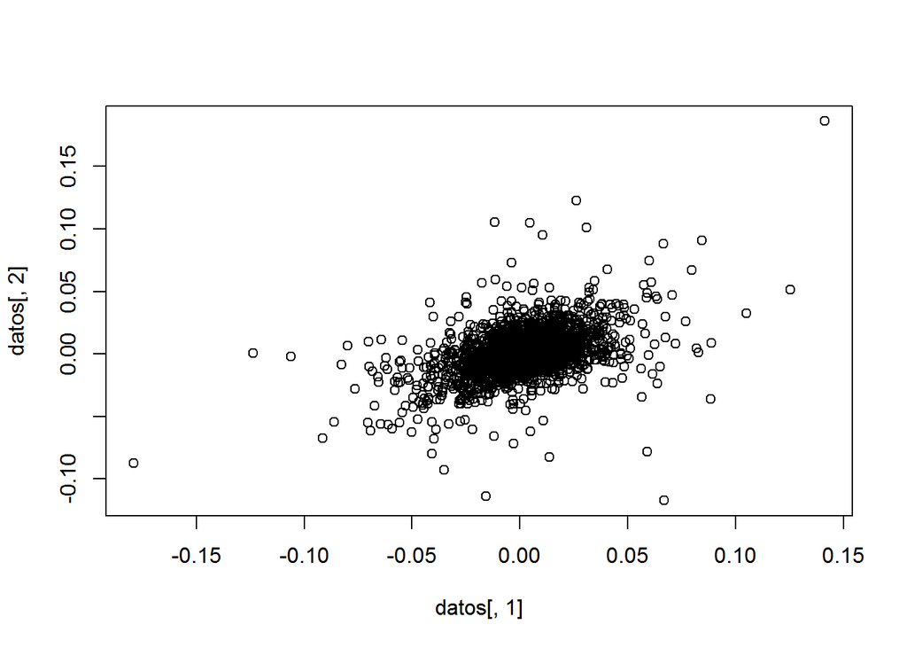

```r
plot(datos[,1], datos[,2])
```

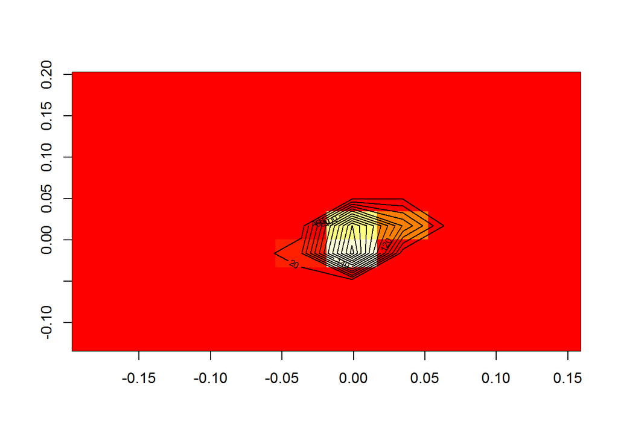

```r
bivn.kde <- kde2d(datos[,1],datos[,2],n=10)
image(bivn.kde)
contour(bivn.kde, add=TRUE)
```

#### APPL vs YHOO

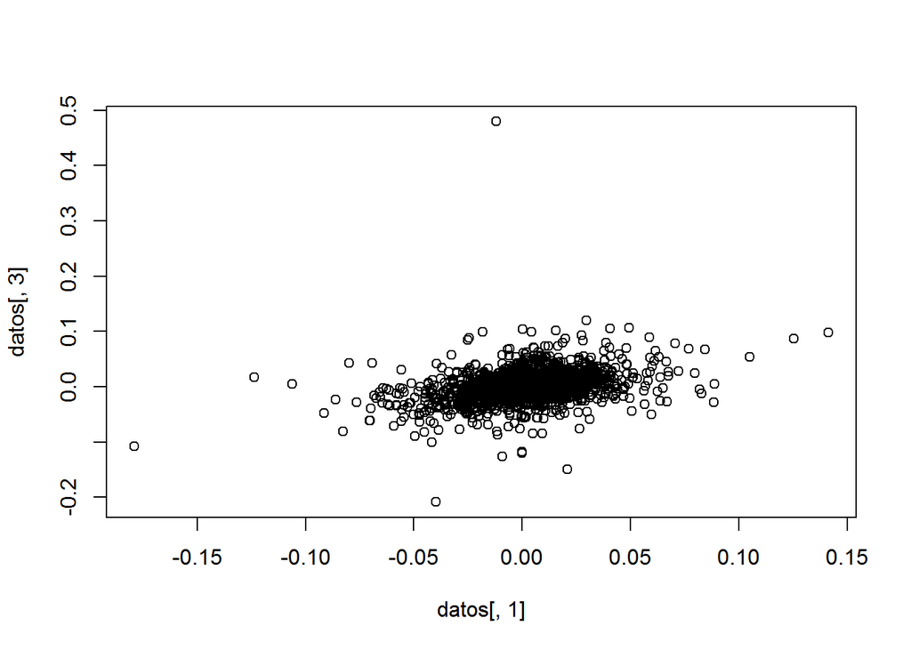

```r
plot(datos[,1], datos[,3])
```

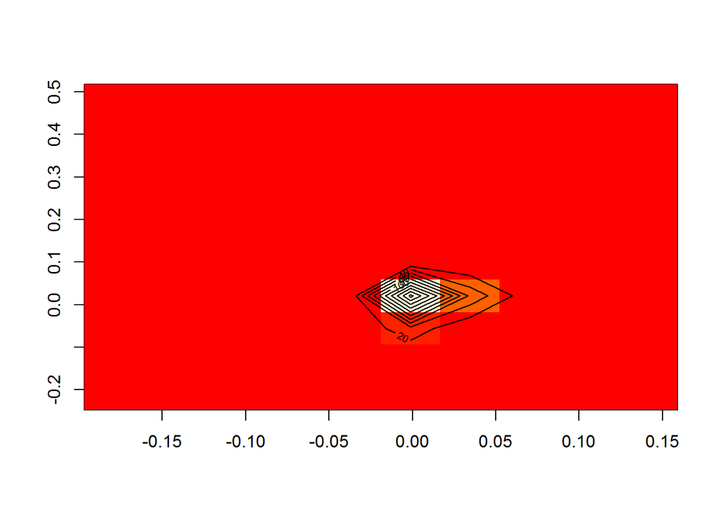

```r
bivn.kde <- kde2d(datos[,1],datos[,3],n=10)
image(bivn.kde)
contour(bivn.kde, add=TRUE)
```

#### MSFT vs YHOO

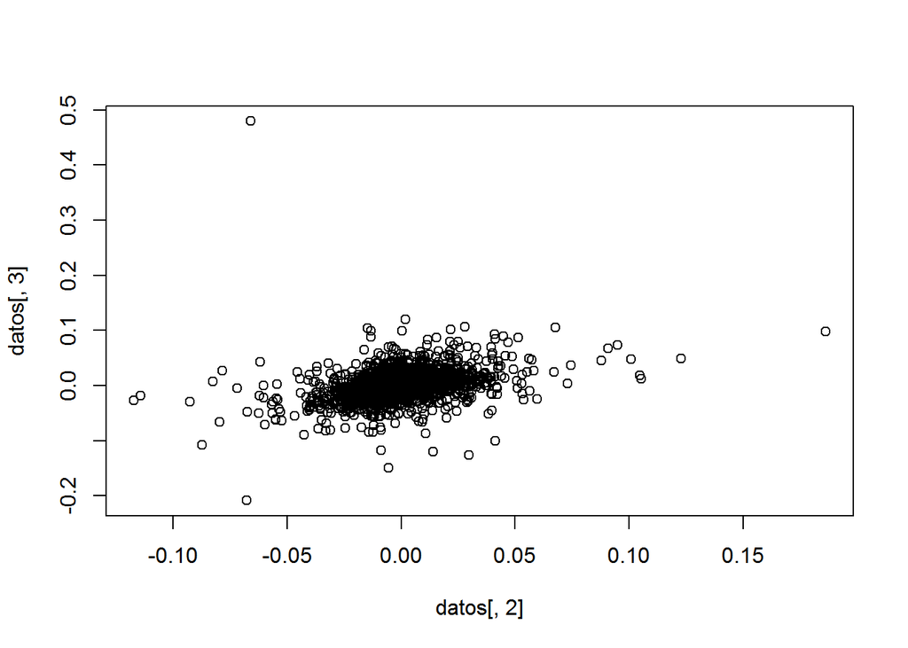

```r
plot(datos[,2], datos[,3])
```

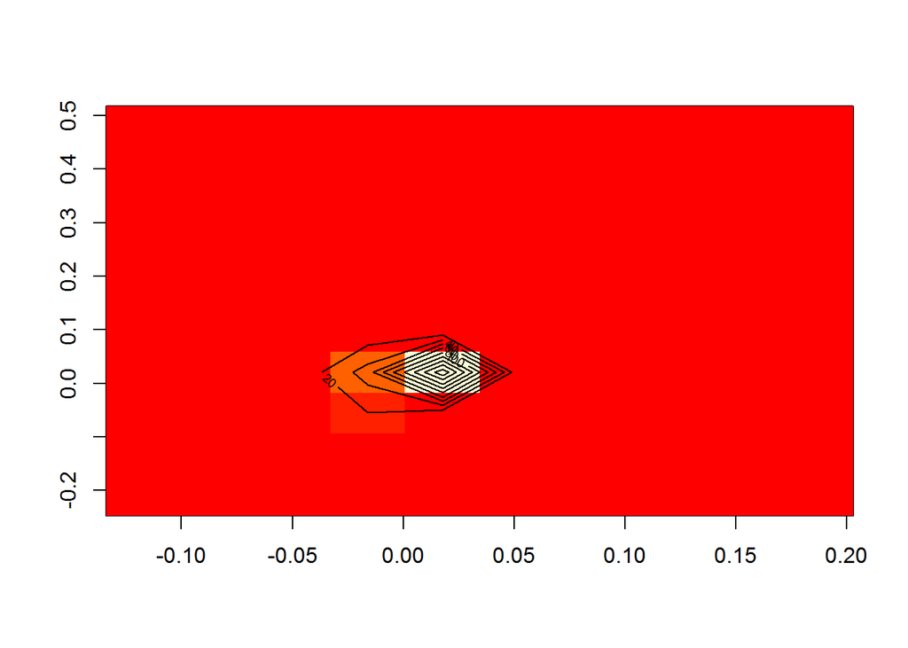

```r
bivn.kde <- kde2d(datos[,2],datos[,3],n=10)
image(bivn.kde)
contour(bivn.kde, add=TRUE)
```

## Referencias

- **Bishop** - Pattern Recognition and Machine Learning.
- **Murphy** - Conjugate Bayesian analysis of the Gaussian distribution